# Effects of Loan Features on the Estimated Return

## by Luiz Iurk

## Investigation Overview

The intention here is to investigate how the choosen features Term, rating and loan amount can affect the estimated return. Additionally, I want to investigate if Loan Category has some effect as well.  
This choice was based on what many economists find as primary foundations for financial planning: Time, Amount and Risk

## Dataset Overview

The original dataset contains 113,937 loan records with 81 features (including LoanStatus, StatedMonthlyIncome, IncomeRange, ProsperRating and many others features that describe the borrower profile).  
Besides removing duplications, since the focus of the analysis is to monitor the Estimated return, only records that contained records in that field were considered relevant, remaining around 83k records in total to be evaluated.

## Distribution of the Estimated Return

The distribution of the Estimated Return is unimodal, but not perfectly distributed, with the biggest peak around 0.1. Some negative values are identified, but not so many (almost insignificant enough to be discarded)

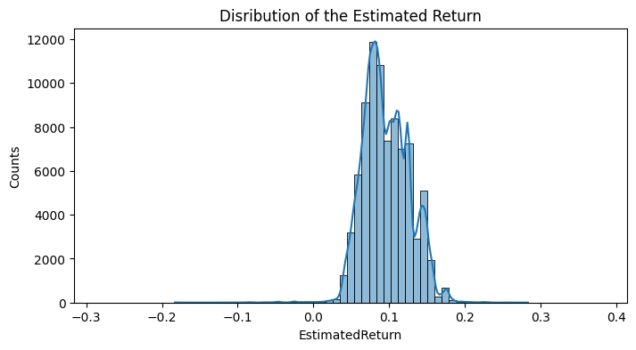

## Distribution of Original Loan Amount

There are some spikes in some key values around 5k, 10k, 15k, 20k, etc. Possibly, there are some default loan values

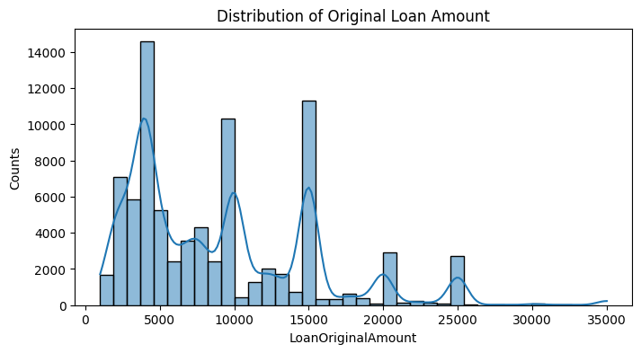

## Estimated Return vs. Original Loan Amount

This plot shows that at different size of the loan amount, the Estimated Return has a large range. Due to the amount of noise, it is hard to see, but if a line was drawn, connecting the lighter points in the chart, we can see that the return decreases with the increase of the loan amount. In other words, the estimated return is negatively correlated with loan amount.

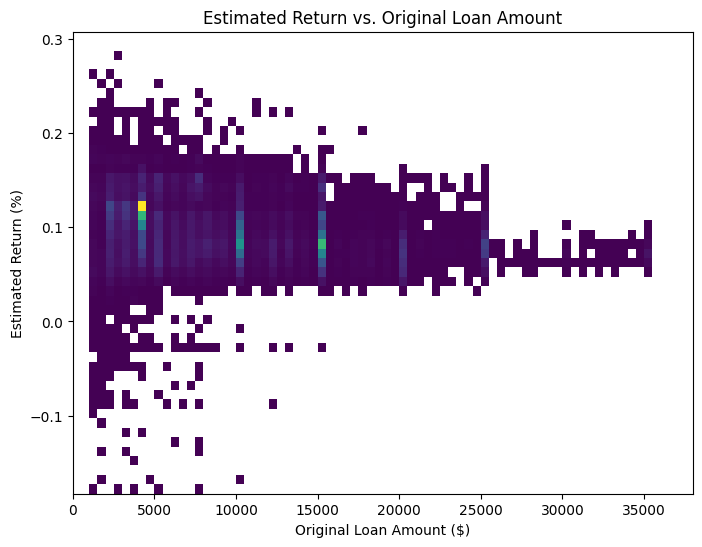

## Estimated Return vs. Prosper Rating

The estimated return decreases the higher the borrower rating is. We can't avoid to tell that there is a lot of outliers in this plot. But one conclusion can be that the Prosper rating has a strong effect on the estimated return.  
In other hand, with the exception of the HR group, the variability of the return decreases the higher the rating is (figure format is wider and shorter). This makes sense, since groups of higher ratings are more financially stable.  
This is a clear example that we should not base our conclusions exclusively on averages.

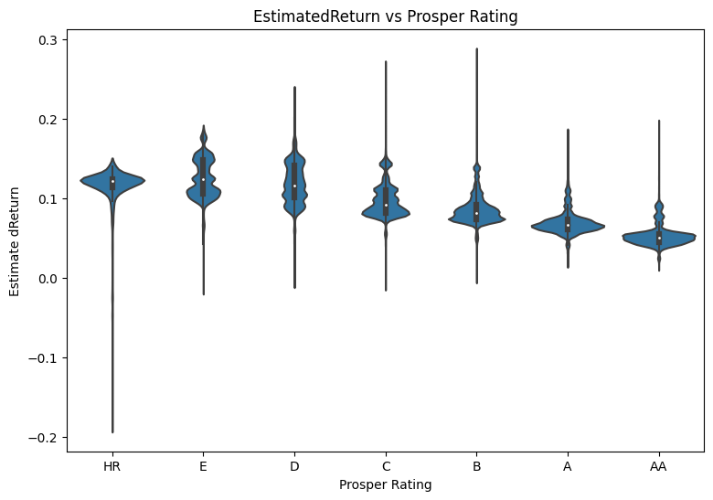

## Prosper Rating Effect on Relationship between the Estimated Return and Loan Amount

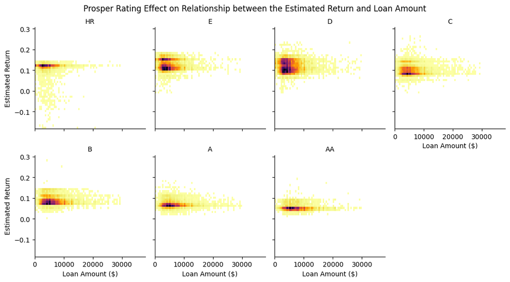

I noticed that there is a different behavior in customers with Incomes up to 10k (less dispersive) in comparison to those with higher incomes.  
To have a clearer view, I split the dataset in two groups and check the return based on Listing Category and Rating.  
It was found that, in general, the return decreases with the increasing of the prosper rating, for all the term bins.  
This analysis reinforced the influence of the Prosper Rating in both groups. Because we see how the return decays along the increasing of the rating.  
The investigation also showed that the Loan Category doesn't change much the estimated return within the same rating group, but we see that there are some categories that have better returns in one risk group in comparison to another. For example, Household expenses in the HR group have a highest return, while in the rating group E, it is the Auto that has the best one.

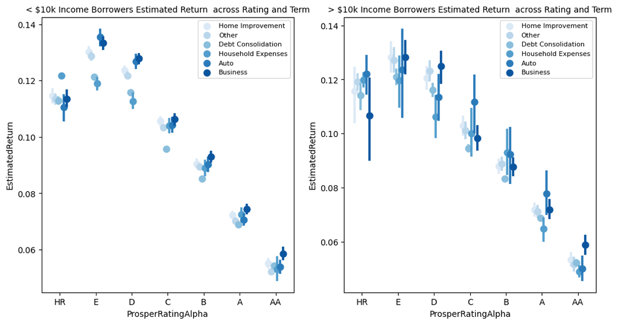

## Estimated Return by Term and Rating for Selected Incomes

Checking the relationship across the Term, it is possible to see that the group with incomes above 10k have a lower Estimated Return gap with the change of the Term, in comparison to the group with a lower income for the Prosper Rating groups above D. The groups from HR to D are showing the highest Mean Estimated Returns, which reinforces the thesis that this group can be profitable for the bank, but preferable from mid to long terms

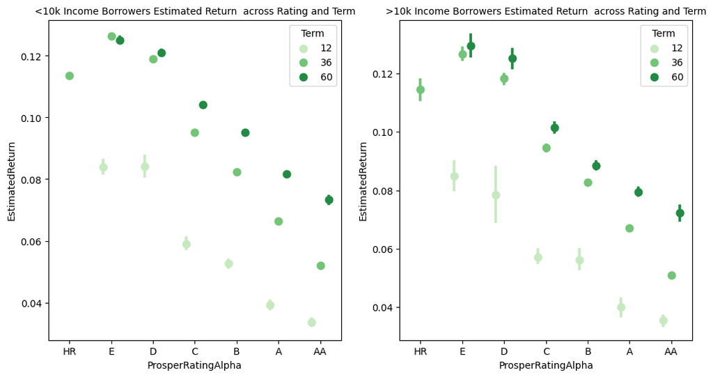